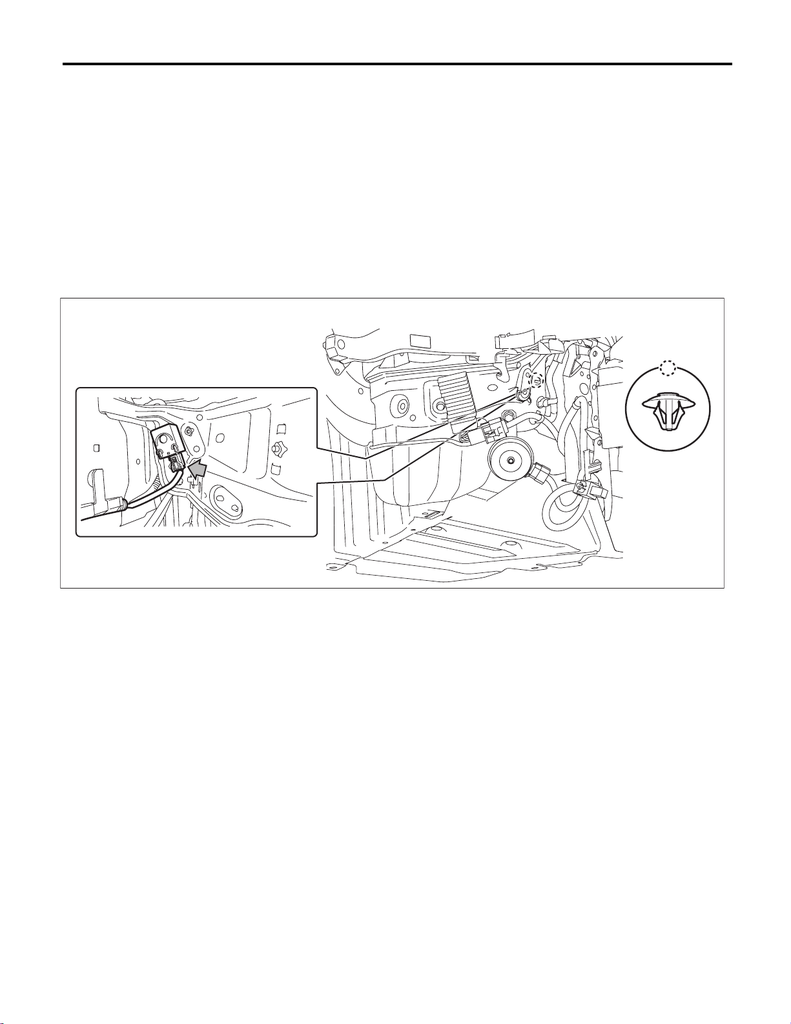

SL-118

Access Buzzer

SECURITY AND LOCKS

42.Access Buzzer

A: REMOVAL

1) Disconnect the ground cable from battery. <Ref. to NT-5, BATTERY, NOTE, Note.>

NOTE:

For models other than STI model, disconnect the ground terminal from battery sensor.

2) Remove the air cleaner case.

• STI model: <Ref. to IN(STI)-9, REMOVAL, Air Cleaner Case.>

• Except for STI model: <Ref. to IN(w/o STI)-9, REMOVAL, Air Cleaner Case.>

3) Lift up the vehicle.

4) Remove the access buzzer.

(1) Disconnect the connector.

(2) Remove the clip and detach the access buzzer.

B: INSTALLATION

1) Install the access buzzer.

2) Install the air cleaner case.

• STI model: <Ref. to IN(STI)-9, INSTALLATION, Air Cleaner Case.>

• Except for STI model: <Ref. to IN(w/o STI)-12, INSTALLATION, Air Cleaner Case.>

3) Connect the battery ground terminal. <Ref. to NT-5, BATTERY, NOTE, Note.>

NOTE:

For models other than STI model, connect the ground terminal to battery sensor.

C: INSPECTION

• Using the Subaru Select Monitor, set the volume of the access buzzer. <Ref. to BC(diag)-20, User Cus-

tomizing.>

• Using the Subaru Select Monitor, perform forced operation of the access buzzer. <Ref. to BC(diag)-20,

OPERATION, User Customizing.>

If the buzzer does not sound, replace the access buzzer.

SL-02877